# index

## Internet Penetration Rate and Local corruption

This plot explore the negative relationship between provincial internet penetration rate and degree of local corruption in different economic zones of China. As the development of E-government in recent years facilitates citizens to supervise government daily operation, provinces with higher internet penetration rate appear to have fewer corruption cases.

This finding implies that better infrastructures can empower citizens to monitor local governments as news media, reshaping the system of anti-corruption institutions.

[Data Source](https://data.stats.gov.cn/index.htm) [Relevant Academic Work](https://www.sciencedirect.com/science/article/abs/pii/S0167624509000110)

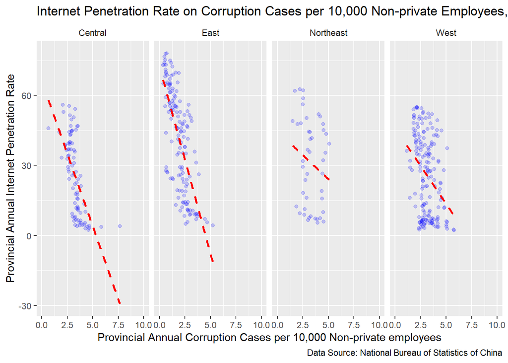

```r
corruption <- corruption %>%
mutate(corruption_per = corruption_officials / non_private_employee)
ggplot(data = corruption,
        mapping = aes(x = corruption_per,
                      y = internet)) +
    geom_point(alpha = 0.2 , color= "blue", position = "jitter") +
    geom_smooth(method="lm", color = "red", linetype = 2, se= FALSE) +
  facet_grid(~region) +
  coord_cartesian(ylim = c(0, 1)) +
  coord_cartesian(xlim = c(0, 10)) +
  labs(title = "Internet Penetration Rate on Corruption Cases per 10,000 Non-private Employees, by Economic Zone",
       caption = "Data Source: National Bureau of Statistics of China",
       x = "Provincial Annual Corruption Cases per 10,000 Non-private employees",
       y = "Provincial Annual Internet Penetration Rate") +
  theme(strip.background = element_blank(),
        legend.title=element_blank())
```

## Different period of government and Local corruption

This plot explore how degree of corruption in different economic zones varied in different period of Chinese government. The Chinese Communist Party (CCP) uses 5 years as cycle to institute national plans and policies. The plot indicates that in different period of 5 years plan the degree of corruption in East, West and Central have gradual decrease due to the reform of Chinese anti-corruption system. But Northeast appears to be an outlier.

This finding implies that Chinese government should pay more attention to the anti-corruption issues in Northeast economic zone.

[Data Source](https://data.stats.gov.cn/index.htm)

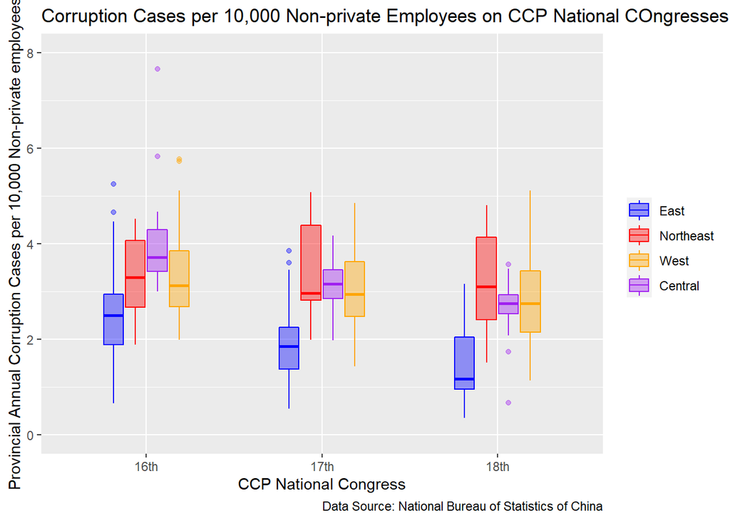

[figure not shown]

```r
corruption <- corruption %>%
  mutate(
    period = case_when(
      year == 2003 ~ "16th",
      year == 2004 ~ "16th",
      year == 2005 ~ "16th",
      year == 2006 ~ "16th",
      year == 2007 ~ "16th",
      year == 2008 ~ "17th",
      year == 2009 ~ "17th",
      year == 2010 ~ "17th",
      year == 2011 ~ "17th",
      year == 2012 ~ "17th",
      year == 2013 ~ "18th",
      year == 2014 ~ "18th",
      year == 2015 ~ "18th",
      year == 2016 ~ "18th",
      year == 2017 ~ "18th"
    ))
period_level <- c("16th","17th","18th")
corruption$period <- factor(corruption$period,
                            levels = period_level)
region_level <- c("East", "Northeast", "Central", "West")
corruption$region <- factor(corruption$region,
                            levels = region_level)
ggplot(data = corruption) +
  geom_boxplot(mapping = aes(x = period,
                             y = corruption_per,
                             fill = region,
                             color = region,
                             outlier.size = 2,
                             outlier.alpha = 0.4),
               width = 0.5,
               alpha = 0.4) +
  scale_fill_manual(values = c("East" = "blue",
                               "Northeast" = "red",
                               "West" = "orange",
                               "Central" = "purple")) +
  scale_color_manual(values = c("East" = "blue",
                               "Northeast" = "red",
                               "West" = "orange",
                               "Central" = "purple")) +
  coord_cartesian(ylim = c(0, 8)) +
  theme(legend.title=element_blank()) +
  labs(title = "Corruption Cases per 10,000 Non-private Employees on CCP National COngresses, by Economic Zone",
       caption = "Data Source: National Bureau of Statistics of China",
       x = "CCP National Congress",
       y = "Provincial Annual Corruption Cases per 10,000 Non-private employees")
```

## Corrupt Officials and GDP

[Data Source](https://data.stats.gov.cn/index.htm)

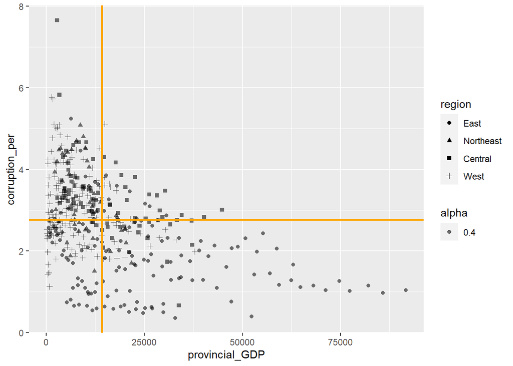

```r
corruption <- corruption %>%
mutate(corruption_per = corruption_officials / non_private_employee)
ggplot(data = corruption, mapping = aes(x = provincial_GDP, y = corruption_per,shape = region, alpha = 0.4)) +
  geom_point() +
  geom_hline(yintercept = 2.7645, color = "orange", size = 1) +
  geom_vline(xintercept = 14243, color = "orange", size = 1)
```

## Corrupt Officials and Provincial Expenditure

[Data Source](https://data.stats.gov.cn/index.htm)

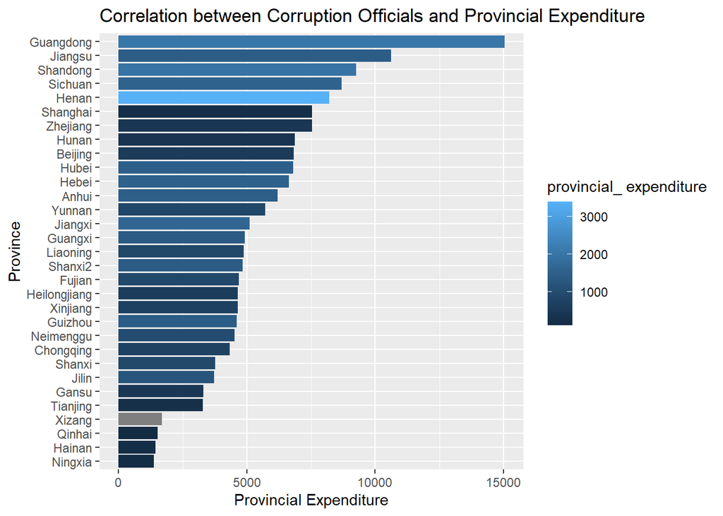

[figure not shown]

```r
corruption %>%
  filter(year == "2017") %>%
  group_by(province) %>%
  ggplot(mapping = aes(x = provincial_expenditure,
                         y = reorder(province, provincial_expenditure),
                         fill = corruption_officials)) +
  geom_bar(stat = "identity")  +
  scale_fill_continuous(name = "provincial_ expenditure") +
  labs(title ="Correlation between Corruption Officials and Provincial Expenditure",
         x = "Provincial Expenditure",
       y = "Province")
```